# N model based on Bray

Christa Torrens

2023-03-03

#### Background

End goal: develop a model to predict [NO3-N] across space and time in rivers, using high-frequency SUNA, PAR, Q (and more…) data.

1st subgoal: Take the model from the Bray thesis; fake 1 day’s worth of data, add process error 2nd subgoal: use the Bray model to fake 111 days worth of data - then add process error 3rd subgoal: Recover parameters? 4th subgoal: Add more hydrology? e.g.: …..

#### Faking data

First, let’s fake 1 day’s worth of data using the UNPOOLED Bray model AND Bray light data (then we’ll try this with more days and then with the POOLED model)

```r
# Load packages
library(scales)
library(magrittr) # moved from  'light ea day as vector'
library(tidyverse)
library(lubridate)
library(streamMetabolizer)
library(rstan)
library(tidybayes)
```

```r
# set seed for consistent results
set.seed(101)

# Load Bray data from Miller Creek
datain<-read.csv("Miller Creek N uptake input.csv")
head(datain) # date, Jday, time, light, z, conc (= N conc)
```

```
##        date Jday time   light         z     conc
## 1 6/25/2019  176    0       0 0.2302286 60.61615
## 2 6/25/2019  176    1       0 0.2263844 60.61615
## 3 6/25/2019  176    2       0 0.2289476 60.12210
## 4 6/25/2019  176    3       0 0.2293781 60.02329
## 5 6/25/2019  176    4       0 0.2257162 60.22091
## 6 6/25/2019  176    5 1016027 0.2241314 61.40663
```

```r
# Bray model - UNPOOLED
# [N]_i = [N]_i-1 + (U/z)(hourly light/total daily light) + K(ambient [N] - [N]_i-1)*dt
# NOTE: dt = 1/24 for hourly timestep

# Param values
K <- 3  # 3-19 in Bray, units = d^-1
U <- -3 # was 0.4-10 mg/m2/day in Bray) # Per Bob - nope, take it back, this needs to scale so stan can work w your se
N_amb <- 57   #In mg, mean = 57.16, sd=11.98) #daily value for N_amb
N <- 55
light1 <- datain$light[5:28]  # For now, using light data from Bray's Miller Creek dataset: 0400 6/25/2019 - 0300 6/26/2019
sumlight <- sum(light1) # daily light
z <- 0.2 #depth in m - constant for now
datetime <- ymd_hms('20190625 040000', tz='America/Denver')
date <- date(datetime)
time.h <- hour(datetime)
Jday <- yday(datetime)
```

#### Generating light data from streamMetabolizer::calc_light

Steps: 1) Need to generate posix datetimes for streamMetabolizer 2) Calculate solar time from local time streamMetabolizer::calc_solar_time 3) Use the solar.time to generate light data using streamMetabolizer::calc_light

```r
### Try this for 1 day (0400 June 25 2019- 0400 June 26 2019) and plug into Bray model (above) using the same parameter values

# STEP 1:
t1 <- ymd_hms('20190625 040000', tz='America/Denver')  # as.numeric = 1561460400 (# seconds since 1970)
#t2 <- ymd_hms('20190626 040000', tz='America/Denver')  # as.numeric = 1561543200 ## for 5 min data
t2 <- ymd_hms('20190626 030000', tz='America/Denver') ## for hourly data
#tseq <- seq(from=as.numeric(t1), to=as.numeric(t2), by=300)  # from a to b in 5-minute timesteps
tseq <- seq(from=as.numeric(t1), to=as.numeric(t2), by=3600) # from a to b in 1-hour timesteps

tseq <- as_datetime(tseq, tz='America/Denver')
head(tseq)
```

```
## [1] "2019-06-25 04:00:00 MDT" "2019-06-25 05:00:00 MDT"
## [3] "2019-06-25 06:00:00 MDT" "2019-06-25 07:00:00 MDT"
## [5] "2019-06-25 08:00:00 MDT" "2019-06-25 09:00:00 MDT"
```

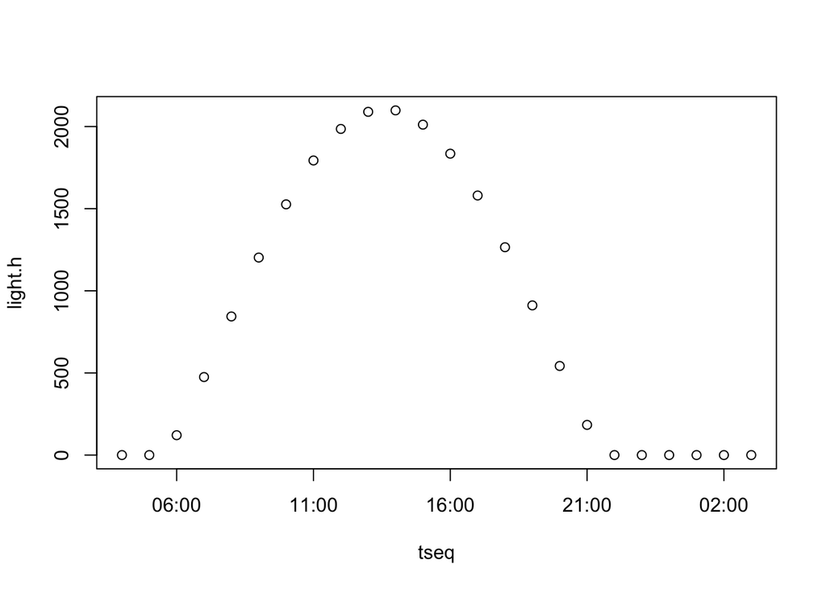

```r
# STEP 2:
tseq.solar <- streamMetabolizer::calc_solar_time(local.time=tseq, longitude=-113.64569089116506)

# STEP 3:
#light.5min <- streamMetabolizer::calc_light(solar.time=tseq.solar, latitude=48.515096115449715, longitude=-113.64569089116506)
light.h <- streamMetabolizer::calc_light(solar.time=tseq.solar, latitude=48.515096115449715, longitude=-113.64569089116506)

plot(tseq, light.h)   # looks fine - but 'sumlight.h' is >3 orders of magnitude too small, need to sum 5-min data to the hour for more accurate light/ sumlight data
```

```r
sumlight.h <- sum(light.h)

##  STUCK HERE - sum 5min data to hourly timesteps
# light.df <- data_frame(tseq, light.5min) %>%
#   group_by(time=ceiling_date(time, 'hour')) %>%
#   summarise(light = sum(light.5min))

light1 <- light.h
sumlight <- sumlight.h
```

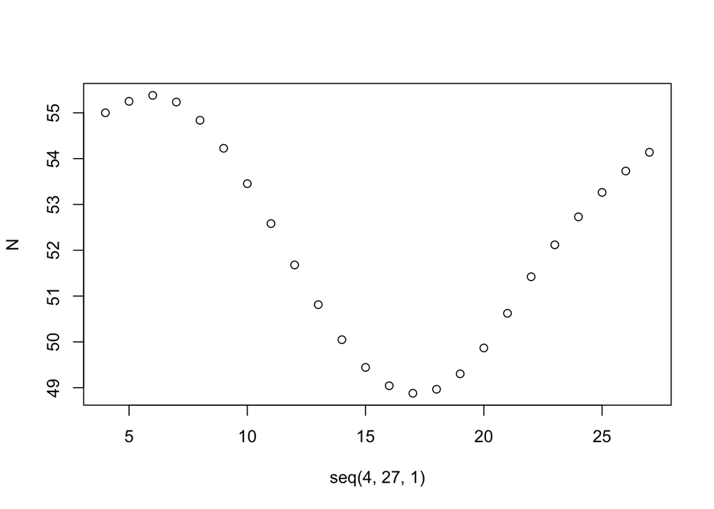

```r
# Data model for one day - no error
# For one day:
for (i in 2:length(light1)) {
  N[i] <- N[i-1] + (U/z)*(light1[i]/sumlight) + K*(N_amb-N[i-1])*1/24
}

plot(seq(4, 27, 1), N)
```

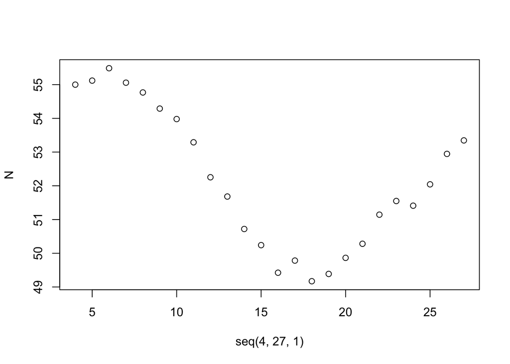

```r
# Data model for one day with process error
# For one day:
for (i in 2:length(light1)) {
  N[i] <- N[i-1] + (U/z)*(light1[i]/sumlight) + K*(N_amb-N[i-1])*1/24  + rnorm(1, mean = 0, sd = 0.4)
}

plot(seq(4, 27, 1), N)
```

```r
## QUESTION - I think the data + error look reasonable - do you agree?

df.fake <- data.frame(date, Jday, time.h, light1, z, N)
```

For Bray’s method, I need to change the data vectors light, z and conc into matrices

```r
###Create variables for stan

nday = 1

###light at each timestep as matrix (col=days, row= hours/day)
lightMA <- matrix(unlist(df.fake$light1), ncol = nday, byrow = FALSE)

###nitrate conc each timestep as matrix (col=days, row= hours/day)
concMA <- matrix(unlist(df.fake$N), ncol = nday, byrow = FALSE)

###sum total light for each day as vector

sumlightgrouped<-df.fake %>% group_by(Jday) %>%
  summarize(sumlight = sum(light1))

sumlight<-(sumlight=sumlightgrouped$sumlight)
head(sumlight)
```

```
## [1] 20465.44
```

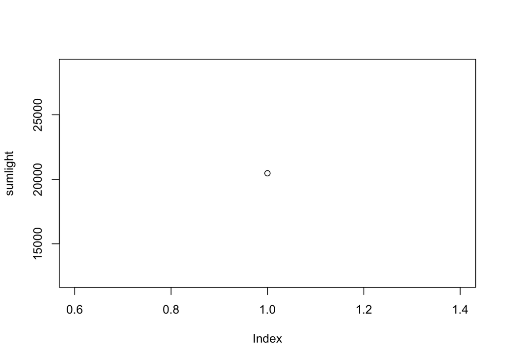

```r
#sumlight

#check sum light
plot(sumlight)
```

```r
###depth aat each timestep as matrix (col=days, row= hours/day)
zMA<- matrix(unlist(df.fake$z), ncol = nday, byrow = FALSE)
```

Now that the data is in the correct form, I create the data list and send the call to stan

#### Data list and call to stan

```r
###merge matrices, vectors,and real numbers into single list
#T=number of hours in a day, D= number of days of sampling, deltat=change in time between time steps (in units of day)

data <- list(T=24,D=nday,deltat=1/24,lightMA=lightMA,sumlight=sumlight,zMA=zMA,concMA=concMA)
fit <- stan("unpooled_ct.stan", data = data,  iter = 1000, chains = 4,control = list(max_treedepth = 15))
```

```
## Trying to compile a simple C file
```

[output not shown]

```
## failed to create the sampler; sampling not done
```

```r
# stan data: lightMA, concMA, deltat, sumlight, zMA, T, D
```

Error messages:

> Error : Exception: mismatch in number dimensions declared and found in context; processing stage=data initialization; variable name=sumlight; dims declared=(1); dims found=() (in ‘model11f6f4aaf76cd_unpooled_ct’ at line 13) In addition: Warning message: In readLines(file, warn = TRUE) : incomplete final line found on ‘/Users/torrensc/Documents/R-working/Modelscapes/space_time_rivers/Bray_code/N uptake/unpooled_ct.stan’ failed to create the sampler; sampling not done

ALSO: -> For our daily model, we ran it from 4a-3:55a, since the previous day will affect the night more than night will affect the following day. -> How to replicate this in a Jday-driven model/ that parallels Bray? -> still need to figure out how to create a more accurate sumlight -> create 5-min data that sum to the hour, which will then sum to the daily ‘sumlight’ variable

```r
## longer timeseries - IN PROCESS

t1 <- ymd_hms('20190625 040000', tz='America/Denver')
t3 <- ymd_hms('20191014 035500', tz='America/Denver') # as.numeric = 1571032800  ## this is for 111 days...
tseq <- seq(from=as.numeric(t1), to=as.numeric(t2), by=300)
tdiff <- as.numeric(t2)-as.numeric(t1)
day <- as.numeric(t2-t1)
```

#### Part Three: pooled model

pool the light data per Bray: >b1 <- 1.1138 >b0 <- -2.803 >pooled_line <- b0+b1*sumlight*1e-6,